# Week 9: spatial analysis / map-making in R

# Preliminaries

Let’s **install the libraries we’ll need for today’s session.** (Do this in the console so you don’t re-install every time you run the script.)

```r
install.packages(c("sf", "tmap"))
```

These are:

- The **Simple features** library. This will do all the clever spatial stuff. Simple features is designed to work with the kind of tidy data workflow you’ve been learning in SMI105. It allows spatial data in R to be manipulated **as if it was a standard dataframe**
- The *tmap* library is a popular way to make maps in R. There are other options, but this works well with the `sf` library and other tidy workflows.

Load them once installed (along with the tidyverse):

```r
library(tidyverse)
library(sf)
library(tmap)
```

## Maps 1: carrying on with last week’s data for Scottish Index of Multiple Deprivation and proportion of people on psychiatric medication

Reminder: this data is from **chapter 11 of Fogarty’s “Quantitative Social Science Data with R”**. We’re going to be attaching to **geographical data** and making some maps.

We’ll look at the **Scottish Index of Multiple Deprivation** from 2020, with each row or observation being a Scottish **datazone** (a small geographical area with about 500-1000 people in each).

Let’s load the data via URL and look at a summary of all the variables:

```r
simd <- read.csv(url('https://bit.ly/smi106simd'))
```

```r
summary(simd)
```

We can use `glimpse` (from the tidyverse) to glimpse at some of the data oriented across. Note that we have some **geographical labels** in this (otherwise non-geographical) dataset.

```r
glimpse(simd)
```

That data is **non-spatial** currently. To make it spatial, we’re going to need to attach it to spatial data.

Our spatial data here is **the set of polygons that describe the geography of Scottish datazones** - matching the datazon-level data from the CSV.

You would normally load spatial data in one of several formats, having downloaded it to your RStudio project folder, using `sf`s `st_read` function. This detects the spatial data format, then loads it into an `sf` dataframe. This would look like this:

**(Just an example, don’t input this code)**

```r
datazones <- st_read('data/mapdata/datazones2011_borders/scotland_dz_2011.shp')
```

But we’ll load an R compressed object version - it’s exactly the same thing, it’s just been saved as and RDS so we can load in over the internet. **Use this code instead!**

```r
datazones <- readRDS(url('https://bit.ly/smi106dz'))
```

Once loaded, as with any other dataframe, it can be viewed by clicking on it in the environment panel, or we could use glimpse:

**We won’t map it yet - this is datazones for the entire of Scotland, it would be difficult to see. We’ll subset in a moment.**

```r
glimpse(datazones)
```

Note the vital column here: `geometry`. This contains the spatial information for the shape of each polygon. There’s one polygon per row in the dataframe.

We can use the `class` function to see how this differs from a standard dataframe. It has an **extra class** that it’s wrapped in, the `sf` class. This does all of the spatial magic stuff. (The `class` function is a very useful way to check what kind of object you’re working with, in case you’re unsure.)

```r
class(datazones)
```

```
## [1] "sf"         "data.frame"
```

Now, we have (1) our SIMD data via CSV, and (2) spatial data for the geography of the datazones. Now we have to **join the two of them**. For this, we can use one of `dplyr`s join functions. There’s a great graphical summary of these on the **dplyr / data wrangling cheatsheet**. Here’s a snippet from it:

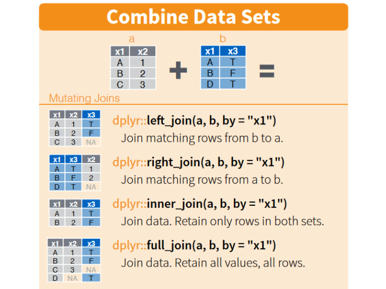

To make a join, we need **matching keys in both the CSV and the `sf` dataframe**. Glimpsing both again…

```r
glimpse(simd)
glimpse(datazones)
```

… there’s a `data_zone` column in the CSV and a `datazone` column in the `sf` dataframe - those look like the right keys. We can deal with the slight column name mismatch in the code.

But first, we should always **check to see if the unique keys in each have a good match**. There may be several reasons why they won’t match - and sometimes we won’t expect them to. If, for instance, our CSV was just English data and the spatial data had zones for the whole of the UK, we’d want to ask: does the spatial data contains keys for all the English data?

```r
#Check datazone code match... tick
table(datazones$datazone %in% simd$data_zone)
```

```
##
## TRUE
## 6976
```

Tick! All good matches. We can proceed with the join in confidence.

Things to note about the join code here:

- Because we’re expecting a perfect match, whether it’s left, right, inner or full join won’t matter - the outcome will be the same.
- We put the **spatial data first** - this will keep it spatial when the join is made
- If the key names don’t match (as they don’t in our case), we specify the names of the specific keys in a vector, with each name in quote marks and linked by an equals (=).

**Let’s call the joined dataset `simd.geo`.**

```r
#Join (using the spatial dataframe as the first argument, so it stays spatial)
simd.geo <- left_join(
  datazones,
  simd,
  by = c("datazone" = "data_zone")
)
```

```r
glimpse(simd.geo)
```

Glimpsing the data, you should see **the SIMD data is now joined to the spatial data**.

One more thing before making maps: we don’t want to plot the entire of Scotland. The SIMD data had `council_area` - what council areas could we subset to? The `unique` function can tell us:

```r
unique(simd.geo$council_area)
```

```
##  [1] "Aberdeen City"         "Aberdeenshire"         "East Lothian"
##  [4] "Angus"                 "Dumfries and Galloway" "East Renfrewshire"
##  [7] "East Ayrshire"         "East Dunbartonshire"   "Fife"
## [10] "Perth and Kinross"     "Renfrewshire"          "North Lanarkshire"
## [13] "Scottish Borders"      "Clackmannanshire"      "City of Edinburgh"
## [16] "Argyll and Bute"       "West Lothian"          "Glasgow City"
## [19] "Dundee City"           "Midlothian"            "Moray"
## [22] "Falkirk"               "North Ayrshire"        "Shetland Islands"
## [25] "South Ayrshire"        "Na h-Eileanan an Iar"  "Highland"
## [28] "Inverclyde"            "South Lanarkshire"     "Orkney Islands"
## [31] "Stirling"              "West Dunbartonshire"
```

Let’s subset to “Glasgow City”. You’ve been using the **pipe operator** in SMI105 - that can be used in combination with `filter` to subset.

> Tip: the shortcut combo for the pipe operator is **SHIFT + CTRL + M** on Windows and **SHIFT + COMMAND + M** on macs.

```r
glasgow <- simd.geo %>%
  filter(council_area == "Glasgow City")
```

**Now we can make maps of Glasgow.** Just starting with something basic, using the `tmap` package - population in each datazone:

```r
tm_shape(glasgow) +
  tm_polygons('totpop2011')
```

But we probably want **population per unit of area**, given the polygons vary in size. The data already includes an area measure, so we can just make a new column using `mutate` that gives us `pop_per_km2`:

```r
#pop per km2 a better measure
glasgow <- glasgow %>%
  mutate(pop_per_km2 = totpop2011 / stdareakm2)
```

**And then make a map.** The `tm_polygons` function takes a variable name we want to map, in quote marks:

```r
tm_shape(glasgow) +
  tm_polygons('pop_per_km2')
```

You’ll note with that map, the **bins** are broken into equal-size bands. It doesn’t usually make for very readable maps. We can **change the style** to improve this. Using **fisher** will cluster in a way that makes more-equal size groups of zones, rather than equal values. (You may also see “jenks” functions doing this; fisher produces very similar results but runs much faster.)

```r
tm_shape(glasgow) +
  tm_polygons('pop_per_km2', style = 'fisher')
```

We can also **choose a different palette** and **set the number of bins to be higher than the default.** And also stick the legend **on the outside of the plot**. Setting `border.alpha` to zero removes the borders (by making them transparent). This can sometimes help to see the polygons better.

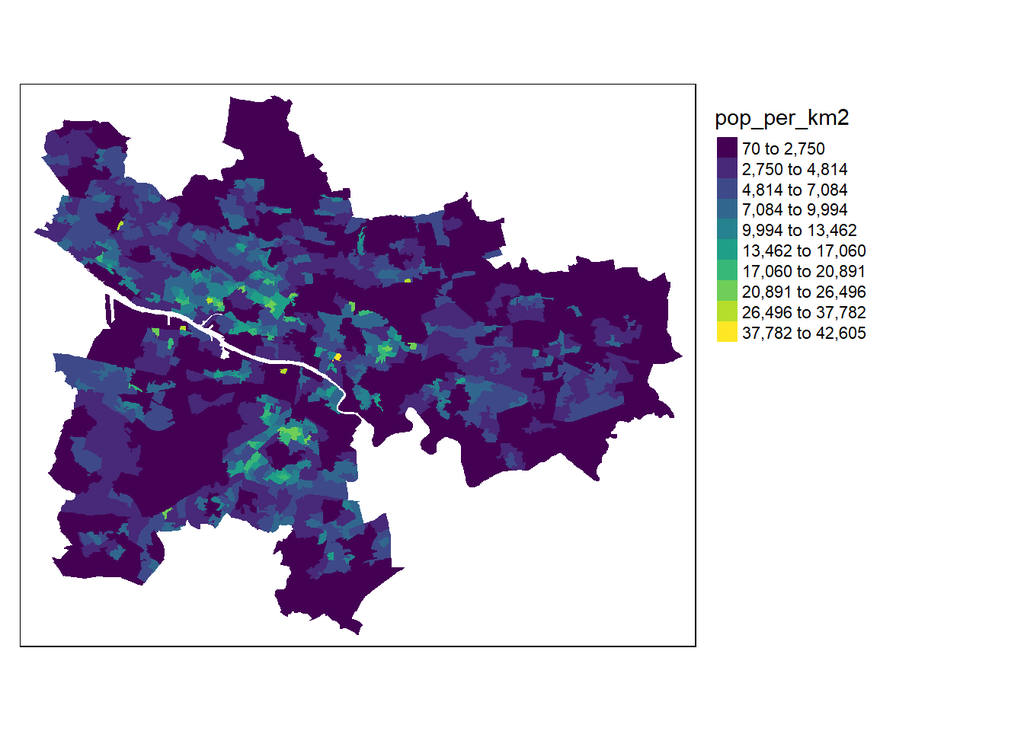

```r
tm_shape(glasgow) +
  tm_polygons('pop_per_km2', style = 'fisher', palette = 'viridis', n = 10, border.alpha = 0) +
  tm_layout(legend.outside = TRUE)
```

You can examine the options to put in the `palette` argument using the following in the console. It’ll give you an interactive window to look at palette options. There’s a button to **open it in the browser** - it’s best to look there and close the first one that opens, as it blocks R from running any other code.

```r
tmaptools::palette_explorer()
```

> **EXERCISE: make two maps using a couple of variables we looked at last week:**
- `pct_depress`: the percentage of each datazones’ population prescribed psychiatric medication
- `pct_income_deprived`: percentage of ‘income deprivation’, one of the 7 domains the index of muliple deprivation contains. This is a **composite measure** made up of other variables.

**All you need to do here: replace `pop_per_km2` in the `tm_polygons` argument with those two variable names.**

Once you’ve looked at those two maps: **is anything striking about the geographical pattern of `pct_depress` and `pct_income_deprived`?**

Note: you can use the back/forward arrows in the ‘plots’ tab to toggle between the two maps.

## Maps 2: Belfast Catholic and Protestant location

Northern Irish Census data has a higher resolution available than anything in the rest of the four nations: there’s **data available at 100m grid squares**. This makes it possible to create very high resolution city maps, as we’ll do next.

We’ll load in an `sf` dataframe for Belfast, with some data already attached.

```r
belfast <- readRDS(url('https://bit.ly/smi106belfast'))
```

```r
glimpse(belfast)
```

A quick map of the just the raw polygons shows us the grid squares:

```r
tm_shape(belfast) +
  tm_polygons()
```

We can make a map of the **count of catholics** in each zone:

```r
tm_shape(belfast) +
  tm_polygons('catholic', palette = "RdYlBu")
```

Which is a reasonable map given all the grid squares are the same size - but still not perfect. We should find the **percentage** of catholics (as a proportion of each grid square’s total population).

Because this is a dataframe, we can do any of our usual column manipulation to it. To make a `percent catholic` columnm, we could *either* use something like this:

```r
belfast$catholic.percent <- (belfast$catholic/belfast$PERSONS)*100
```

… or we can use the `mutate` function (part of the tidyverse) to create the column. It can look a little bit tidier. We overwrite the whole dataframe, having piped the whole thing into the `mutate` function:

```r
belfast <- belfast %>%
  mutate(catholic.percent = (catholic/PERSONS) * 100)
```

Now we can make a map of the proportion of catholics per grid square. With a diverging palette, this makes the segregation much more clear:

```r
tm_shape(belfast) +
  tm_polygons('catholic.percent', palette = "RdYlBu")
```

> **`tmap` gives us two viewing options. We can “plot”, or we can use “view” to see our map data in an interactive view. This option lets us add underlying base layers that can help us explore our data and see where it is.**

Change the map mode now:

```r
tmap_mode("view")
```

```r
tm_basemap('OpenStreetMap.Mapnik') +
  tm_shape(belfast) +
  tm_polygons('catholic.percent', palette = "RdYlBu", alpha = 0.6)
```

Clicking on **zoom** brings up a larger version that’s easier to explore.

It’s possible to **export these interactive maps** so they can be opened in browsers. Just use the **export** option in the Viewer panel and choose **“save as web page”.**

## Maps 3: English Index of Multiple Deprivation - local authority summaries

The different UK nations have their own Indices of Multiple Deprivation that can’t be directly compared. Let’s look at the English version from 2019 next. Our data will be **at local authority level**, with summaries of average IMD scores for **all smaller zones within each local authority** (we’ll use “LA” as shorthand for local authority).

As before, let’s load CSV data for the english IMD, and spatial polygons for the local authority map:

```r
eimd <- read_csv(url("https://bit.ly/smi106ladata"))

la.geo <- readRDS(url("https://bit.ly/smi106lasf"))
```

Check the class of each, and `glimpse` each too (where we see both have 326 rows, one for each local authority):

```r
glimpse(eimd)
class(eimd)

glimpse(la.geo)
class(la.geo)
```

Before we make more maps, set the `tmap_mode` back to **plot** so we’re not viewing interactively.

```r
tmap_mode('plot')
```

We can **plot a map of the empty LA data** to see what it looks like:

```r
#plot empty la map
tm_shape(la.geo) +
  tm_polygons()
```

And again - we want to **join** the CSV to the spatial polygons, but before that, we check if the keys match. Having `glimpse`d, it looks like there’s no other key apart from **the local authority name**. Do they match?

```r
#Do checks to see if match
table(eimd$n %in% la.geo$NAME)
```

```
##
## FALSE  TRUE
##    11   315
```

Uh oh - eleven names **do not match**. This now requires a little detective work to figure out if we can do anything about it. This is fairly normal for getting joins to work - you have to do a bit of digging and look at what matches / what doesn’t match.

So = **which 11 names do *not* match?** We can use our trusty friend `%in%` again. We’ll ask the following - this tells us which ones are not a perfect match, and what they look like:

1. For the vector of local authority names in `eimd`, which are **not** in the map data?
2. For the vector of local authority names in `la.geo`, which are **not** in the eimd data?

```r
eimd$n[!eimd$n %in% la.geo$NAME]
```

```
##  [1] "Herefordshire  County of"     "King s Lynn and West Norfolk"
##  [3] "Stoke on Trent"               "Stratford on Avon"
##  [5] "Kingston upon Hull  City of"  "Bristol  City of"
##  [7] "Newcastle under Lyme"         "Southend on Sea"
##  [9] "Stockton on Tees"             "Barrow in Furness"
## [11] "St  Helens"
```

```r
la.geo$NAME[!la.geo$NAME %in% eimd$n]
```

```
##  [1] "Herefordshire, County of"     "Southend-on-Sea"
##  [3] "Stockton-on-Tees"             "King's Lynn and West Norfolk"
##  [5] "Stratford-on-Avon"            "Kingston upon Hull, City of"
##  [7] "Barrow-in-Furness"            "Newcastle-under-Lyme"
##  [9] "Stoke-on-Trent"               "St. Helens"
## [11] "Bristol, City of"
```

We can see the offending names are actually close matches - just with some punctuation differences. This is quite common. In this case, it’s easy to fix by **removing the offending punctuation in la.geo using `gsub`**. We’ll do that for each bit of punctuation, replacing with a space.

Note: **the full stop needs escape backslashes, as by itself, it’s a code meaning “match everything”**.

```r
la.geo$NAME <- gsub(pattern = ",", replacement = " ", x = la.geo$NAME)
la.geo$NAME <- gsub(pattern = "-", replacement = " ", x = la.geo$NAME)
la.geo$NAME <- gsub(pattern = "'", replacement = " ", x = la.geo$NAME)
la.geo$NAME <- gsub(pattern = "\\.", replacement = " ", x = la.geo$NAME)
```

Now, re-check the match… should be a tick.

```r
#And now they ALL match
table(eimd$n %in% la.geo$NAME)#tick!
```

```
##
## TRUE
##  326
```

And now they all match, **we can do the join.** Again, the key names aren’t quite the same, so we tell the join function what each name is. And we put the spatial dataframe **first**:

```r
eimd.geo <- left_join(
  la.geo,
  eimd,
  by = c("NAME" = "n")
)
```

Check the result:

```r
glimpse(eimd.geo)
```

Looking at the variables, they include each local authority’s mean and median IMD value, both for 2015 and 2019. Let’s **make a map of mean IMD per local authority for 2019**. Lower values (toward red) are more deprived, higher values (toward blue) are less deprived.

Note: because this is using IMD rank, splitting into even bins actually works quite well as a map.

```r
tm_shape(eimd.geo) +
  tm_polygons('mean2019',palette = "RdYlBu", n=10)
```

> **EXERCISE: Another way to look at the same data is to use a *hexmap*. Repeat the same steps we just did, but using hex map data for local authorities instead. The steps are:**
1. Load the hexmap data:

```r
eng.hex <- readRDS(url('https://bit.ly/smi106hex'))
```

```r
glimpse(eng.hex)
```

2. Take a look at the raw polygon data as a map:

```r
tm_shape(eng.hex) +
  tm_polygons()
```

Check local authority name match with IMD data… tick

```r
table(eimd$n %in% eng.hex$n)
```

Given the keys match, **carry out the join**. The code is the same as above, nearly. The only difference here - rather than:

```r
by = c("NAME" = "n")
```

… because the column names are the same in both, you can just use:

```r
by = "n"
```

And of course **substitute `eng.hex` in where `la.geo` was.**

Then, using `tmap`, make a map. Again, this is pretty much exactly the same code as above for `eimd.geo`, just replacing with `eimd.hex`.

One you’ve done that, try adding the following to the map.

1. Firstly, load an English region overlay:

```r
engregion.hex <- readRDS(url('https://bit.ly/smi106regions'))
```

2. Add the following onto the end of your hexmap code (with a plus, as you would with ggplot) to put the overlay over the top, and move the legend outside the plot:

```r
  tm_shape(engregion.hex) +
  tm_borders(col = 'black',lwd = 3) +
  tm_layout(legend.outside = TRUE)
```

You should get something like the following:

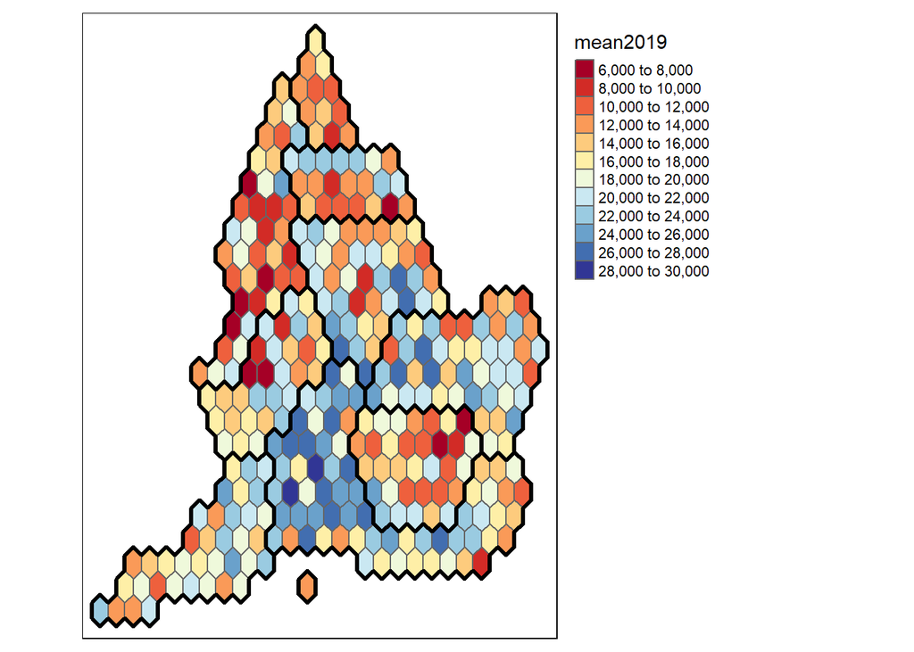

> **You can also try `tmap_mode('view')`: this will allow you to hover the cursor over zones to find out the names of the local authorities, and to click on them to get specific zone values.**

## Maps 4: Country of Birth since 1971

Completing maps from each of the four nations, here’s a Welsh map. This uses our 5 Census Great Britain data on country of birth.

Let’s load the CSV and the geographical zones, as before.

```r
cob.props <- read_csv(url('https://bit.ly/smi106cobprops'))
zones <- readRDS(url('https://bit.ly/smi106cobzones'))
```

```r
glimpse(cob.props)
glimpse(zones)
```

You’ll see the data includes `censusYear`. If we look at the unique values of that column, we can see there is data for five Censuses.

```r
unique(cob.props$censusYear)
```

```
## [1] 1971 1981 1991 2001 2011
```

Let’s check there’s a zone match between the CSV and the spatial data before joining.

```r
table(cob.props$zone %in% zones$zone)
```

```
##
##  TRUE
## 50900
```

Looks OK, we can join them.

```r
#Merge spatial zones with CoB data
cob.props.geo <- left_join(zones,cob.props,by='zone')
```

Look again at the list of different country of birth proportions we’ve got in the columns:

```r
names(cob.props.geo)
```

```
##  [1] "zone"           "merges"         "country"        "ttwa"
##  [5] "censusYear"     "England"        "Scotland"       "Wales"
##  [9] "Irish Republic" "Rest of UK"     "India"          "Pakistan"
## [13] "Europe"         "Rest of world"  "nonUK"          "geometry"
```

We’ve got **England** as a country of birth - so we can **see how much the proportion of English-born people has changed in Wales between 1971 and 2011.**

We start by filtering down to `country == 'Wales'` before using `tmap` to make a **facetted map**. We’ll also filter down to **just the first and last Census year in the data**.

```r
wales <- cob.props.geo %>%
  filter(country == 'Wales',  censusYear %in% c(1971,2011))
```

**Now we can map it.**

> **Make sure you change to `tmap_mode('plot')` if you’d set it to `view` before.**

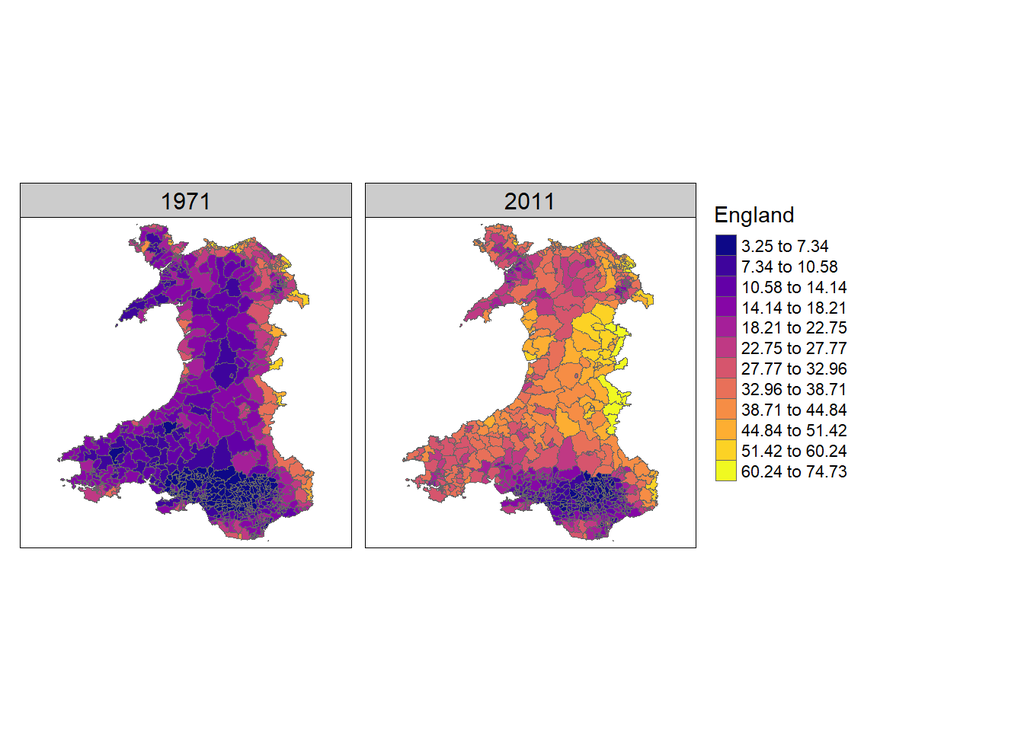

```r
tm_shape(wales) +
  tm_polygons(col = 'England', style = 'fisher', n = 12, palette = 'plasma') +
  tm_facets(by = 'censusYear', ncol = 2) +
  tm_layout(asp=1)#aspect ratio, width/height (per facet)
```

> **EXERCISE: Make a similar map for London. You’ll need to think about the following:**
- Rather than filtering to `country == 'Wales`, filter to `ttwa == 'London'`
- (But still filter to the first and last Census year)
- This time, use the `nonUK` column in the `tm_polygons` col argument - this is the proportion of all non-UK born people
- Try `border.alpha = 0` in the `tm_polygons` function to see what difference it makes.